# Building an inverted index

### Tokenize and Filter text

```python
data["words"] = data["text"].apply(lambda x: word_tokenize(x))

# Remove words that don't have at least one alphabetical character
data["words"] = data["words"].apply(lambda words: list((word for word in words if any(c.isalnum() for c in word))))

# Remove hyphen at end of word
data["words"] = data["words"].apply(lambda words: list(word[:-1] if word[-1] == '-' else word for word in words))

# Split words joined by en dash
data["words"] = data["words"].apply(lambda words: list(word for line in words for word in line.split('–')))
# different encoding
data["words"] = data["words"].apply(lambda words: list(word for line in words for word in line.split('—')))

# Split words joined by dot if they are alphabetical
data["words"] = data["words"].apply(lambda words: split_spread_words(words, '.'))

# Remove lone punctuation from the splits
data["words"] = data["words"].apply(lambda words: list(word for word in words if any(c.isalnum() for c in word)))

# Remove stopwords
data["words"] = data["words"].apply(lambda words: list(word for word in words if word.lower() not in default_stopwords))
```

```python
data.head()
```

|  | title | subtitle | author | date | section | text | url | words |
| --- | --- | --- | --- | --- | --- | --- | --- | --- |
| 0 | “A sociedade foi Rubens Paiva não os facínora... | A decisão da juíza que proíbe as Forças Armada... | F. M. | 30/03/2019 00:11:08 | Brasil | A juíza federal Ivani Silva da Luz de Brasíli... | https://brasil.elpais.com/brasil/2019/03/26/po... | [juíza, federal, Ivani, Silva, Luz, Brasília, ... |
| 1 | Justiça suspende decisão que proibia Forças Ar... | Liminar havia sido concedida na sexta-feira a ... | Marina Rossi | 30/03/2019 16:17:59 | Brasil | Menos de 24 horas depois de a juíza federal Iv... | https://brasil.elpais.com/brasil/2019/03/30/po... | [Menos, 24, horas, juíza, federal, Ivani, Silv... |
| 2 | Governo Bolsonaro prega “negacionismo históric... | Marcos Napolitano professor da USP diz que o... | Regiane Oliveira | 04/04/2019 22:37:48 | Brasil | Quando determinou que de 31 de março 1964 u... | https://brasil.elpais.com/brasil/2019/04/05/po... | [determinou, 31, março, 1964, estratégia, polê... |
| 3 | Quando os pais de Gabo perceberam que tinham u... | Gustavo Tatis percorre o universo de García Má... | Jesús Ruiz Mantilla | 07/03/2019 16:38:56 | Cultura | Quando era pequeno Luisa e Gabriel se preo... | https://brasil.elpais.com/brasil/2019/03/06/cu... | [pequeno, Luisa, Gabriel, preocupavam, menino,... |
| 4 | Rádios canadenses banem músicas de Michael Jac... | Quebec Cogeco Media toma a decisão após queixa... | Jaime Porras Ferreyra | 07/03/2019 16:12:37 | Cultura | Desde a manhã da última segunda-feira e ... | https://brasil.elpais.com/brasil/2019/03/06/cu... | [Desde, manhã, última, segunda-feira, sucessos... |

## Inverted Index with Frequency

```python
inverted_index = {}
for doc_id, text in enumerate(data["words"]):
    fdist = FreqDist(text)
    for word in fdist:
        freq = fdist[word]
        if word not in inverted_index:
            inverted_index[word] = []

        inverted_index[word].append((doc_id,freq))
```

```python
rows = []
columns = ["word","doc_id:freq"]
for word in inverted_index:
    row = [word, inverted_index[word]]
    rows.append(row)

index_df = pd.DataFrame(rows, columns=columns)
display(Markdown("***"))
display(Markdown("### Resulting Inverted Index"))
display(HTML(index_df.sample(15).to_html(index=False)))
display(Markdown("***"))
```

Resulting Inverted Index

| word | doc_id:freq |
| --- | --- |
| estatal | [(35, 1), (125, 1), (138, 1), (141, 3), (161, ... |
| violentos | [(30, 1), (114, 1), (166, 1), (174, 1), (183, ... |
| STEM | [(109, 1)] |
| pego | [(118, 1)] |
| prescinde | [(18, 1)] |
| vergonha | [(3, 1), (8, 1), (18, 1), (148, 1), (150, 3), ... |
| inquisidores | [(239, 1)] |
| culposo | [(4, 1)] |
| traidor | [(62, 3)] |
| avaliou | [(204, 1), (224, 1)] |
| consigo | [(137, 1), (181, 1)] |
| atividade-fim | [(75, 1)] |
| Sasha | [(62, 1)] |
| Gaya | [(13, 1)] |
| ritmo | [(27, 1), (85, 1), (95, 1), (107, 1), (123, 1)... |

```python
# index_df.to_csv("../output/inverted_index.csv", index=False)
```

# Retrieval Approaches

## Implementation

### Document At A Time Retrieval

```python
def retrieve_by_doc(index, query, k):
    try:
        import Queue as Q  # ver. < 3.0
    except ImportError:
        import queue as Q

    result = []
    q = Q.PriorityQueue()
    L = index.loc[lambda df: df.word.isin(query)]

    all_docs = set(index["doc_id:freq"].\
                   apply(lambda pairs: list(doc_id for doc_id, freq in pairs)).sum())

    base_documents = L["doc_id:freq"].sum()

    for doc in all_docs:
        score = base_documents

        if score == 0:
            pass

        elif score == []:
            score = 0
        else:
            score = [fq for d_id, fq in score if d_id == doc]
            if score != []:
                score = reduce(lambda a,b : a+b,score)
            else:
                score = 0

        q.put(((-1) * score,doc))

    i = 0
    while not q.empty() and i < k:
        pair = q.get()
        pair = ((-1) *pair[0],pair[1])
        if pair[0] > 0:
            result.append(pair)
        i += 1

    return result
```

### Term At A Time Retrieval

```python
def retrieve_by_term(index, query, k):
    try:
        import Queue as Q  # ver. < 3.0
    except ImportError:
        import queue as Q

    A = {}
    result = []
    R = Q.PriorityQueue()
    q = Q.PriorityQueue()
    L = index.loc[lambda df: df.word.isin(query)]

    if not L.empty:
        for doc_id, freq in L["doc_id:freq"].sum():
            if doc_id not in A:
                A[doc_id] = 0

            A[doc_id] += freq

        for doc_id, score in A.items():
            q.put(((-1) * score,doc_id))

        i = 0
        while not q.empty() and i < k:
            pair = q.get()
            pair = ((-1) *pair[0],pair[1])
            result.append(pair)
            i += 1

    return result
```

## Placing some queries

Let's place 5 queries to each algorithm (with k = 10)

```python
k = 10
```

```python
queries_df = pd.DataFrame(["criativo","Instagram","reprodução","real","hostil"],columns=["word"])
queries_df["word"] = queries_df["word"].apply(lambda x: [x])
queries_df["by_doc"] = queries_df["word"].apply(lambda w: retrieve_by_doc(index_df, w, k))
queries_df["by_term"] = queries_df["word"].apply(lambda w: retrieve_by_term(index_df, w, k))
```

```python
pd.set_option('max_colwidth', -1)
display(Markdown("***"))
display(Markdown("### Result by Algorithm"))
display(HTML(queries_df.to_html(index=False)))
display(Markdown("***"))
```

Result by Algorithm

| word | by_doc | by_term |
| --- | --- | --- |
| [criativo] | [(2, 35), (1, 150)] | [(2, 35), (1, 150)] |
| [Instagram] | [(1, 85), (1, 110), (1, 151), (1, 229), (1, 242)] | [(1, 85), (1, 110), (1, 151), (1, 229), (1, 242)] |
| [reprodução] | [(2, 160), (1, 88), (1, 123), (1, 140), (1, 196)] | [(2, 160), (1, 88), (1, 123), (1, 140), (1, 196)] |
| [real] | [(3, 213), (2, 30), (2, 85), (2, 137), (2, 188), (1, 18), (1, 25), (1, 27), (1, 36), (1, 40)] | [(3, 213), (2, 30), (2, 85), (2, 137), (2, 188), (1, 18), (1, 25), (1, 27), (1, 36), (1, 40)] |
| [hostil] | [(1, 94), (1, 216)] | [(1, 94), (1, 216)] |

## Is the implementation correct?

Comparing the results of both algorithms for each *single term query* side by side we can see that results are consistent regarding:

- The results are the same for both algorithms, this at the very least shows that the results are consistent

```python
index_df.loc[index_df['word'].isin(['juíza','Luz','Ivani'])]
```

|  | word | doc_id:freq |
| --- | --- | --- |
| 0 | juíza | [(0, 2), (1, 1)] |
| 2 | Ivani | [(0, 1), (1, 1)] |
| 4 | Luz | [(0, 3), (1, 1), (124, 1)] |

Taking the aforementioned in account this would give us the following (sorted by score):

- retrieve by document: [(6,0), (3,1), (1,124)]
- retrieve by document: [(6,0), (3,1), (1,124)]

```python
display(Markdown("##### So, for k = 2 we should have identical results:"))
display(Markdown("###### (we should see *[(6,0), (3,1)]* for both)"))
print("retrieve by term, k=2: {}".format(retrieve_by_term(index_df, ['juíza','Luz','Ivani'], 2)))
print("retrieve by doc, k=2: {}".format(retrieve_by_doc(index_df, ['juíza','Luz','Ivani'], 2)))

display(Markdown("##### So, for k = 3 we should have identical results:"))
display(Markdown("###### (we should see *[(6,0), (3,1), (1,124)]* for both)"))
print("retrieve by term, k=2: {}".format(retrieve_by_term(index_df, ['juíza','Luz','Ivani'], 3)))
print("retrieve by doc, k=2: {}".format(retrieve_by_doc(index_df, ['juíza','Luz','Ivani'], 3)))
```

So, for k = 2 we should have identical results:

(we should see *[(6,0), (3,1)]* for both)

```
retrieve by term, k=2: [(6, 0), (3, 1)]
retrieve by doc, k=2: [(6, 0), (3, 1)]
```

So, for k = 3 we should have identical results:

(we should see *[(6,0), (3,1), (1,124)]* for both)

```
retrieve by term, k=2: [(6, 0), (3, 1), (1, 124)]
retrieve by doc, k=2: [(6, 0), (3, 1), (1, 124)]
```

> The results match and thus we have some evidence that the implementation is correct.

## Comparison in terms of time and memory

Let's pickle (serialize) the words that make up our index to easily use them in an experiment about performance

```python
df = pd.read_csv("../output/inverted_index.csv")
df["doc_id:freq"] = df["doc_id:freq"].apply(lambda x: list(literal_eval(x)))

all_words = list(df["word"].values)
#pickle.dump(all_words, open( "all_words.p", "wb" ))
```

### Experiment Design

Experiment was run using a bash script and auxiliary python scripts that can be found at the [original repository](https://github.com/Benardi/bochica/tree/master/code)

Factors:

- `k` = number of retrieved documents (at most), 1..10
- `n_words` = number of words in the query, 1..15

Metrics:

- `RSS` = Maximum resident set size of the process during its lifetime, in Kilobytes.
- `elapsed` = Elapsed real (wall clock) time used by the process, in [hours:]minutes:seconds.
- `cpu.sys` = Total number of CPU-seconds used by the system on behalf of the process (in kernel mode), in seconds.
- `.user` = Total number of CPU-seconds that the process used directly (in user mode), in seconds.

> For each of the factors' levels we shall have a number of *30* repetitions, which gives us **10 *15* 30 executions**

```python
def get_sec(time_str):
    m, s = time_str.split(':')
    return float(m) * 60 + float(s)
```

```python
exp_results = pd.read_csv('../output/perf_result.csv')
exp_results["elapsed"] = exp_results["elapsed"].apply(lambda x: get_sec(x))
exp_results.sample(5)
```

|  | RSS | elapsed | cpu.sys | .user | k | n_words | approach | execution |
| --- | --- | --- | --- | --- | --- | --- | --- | --- |
| 8961 | 84316 | 1.48 | 0.05 | 1.43 | 10 | 14 | by_term | 22 |
| 15 | 89296 | 9.73 | 1.92 | 7.79 | 1 | 1 | by_document | 16 |
| 6938 | 84356 | 1.47 | 0.06 | 1.40 | 8 | 7 | by_term | 9 |
| 1121 | 89012 | 8.26 | 1.44 | 6.82 | 2 | 8 | by_document | 12 |
| 7738 | 84352 | 1.31 | 0.04 | 1.26 | 9 | 3 | by_term | 29 |

### Elapsed Time

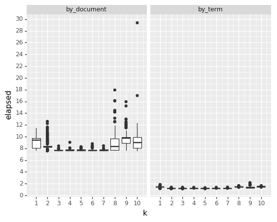

```python
(ggplot(exp_results)
 + geom_boxplot(aes('k', 'elapsed', group='k')) +
 facet_wrap('~approach') +
 scale_x_continuous(breaks = range(0,11,1)) +
 scale_y_continuous(breaks = range(0,32,2))
)
```

- Throughout all values of *k* considered we can see quite clearly that the algorithm **by_document** seems to be at least four times slower than its counterpart **by_term**

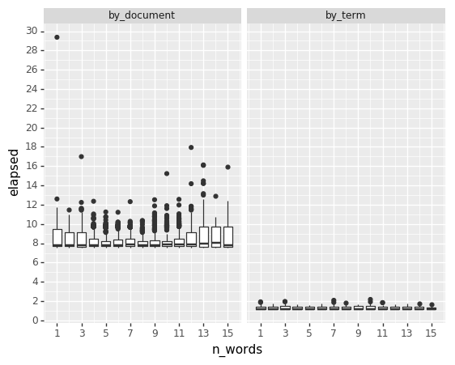

```python
(ggplot(exp_results)
 + geom_boxplot(aes('n_words', 'elapsed', group='n_words')) +
 facet_wrap('~approach') +
 scale_x_continuous(breaks = range(1,18,2)) +
 scale_y_continuous(breaks = range(0,32,2))
)
```

- Throughout all values of **number of words in query** considered we can see quite clearly that the algorithm **by_document** seems to be at least four times slower than its counterpart **by_term**.

> Overall in terms of time the algorithm **by_document** seems slower than the algorithm **by_term**

#### Kernel mode

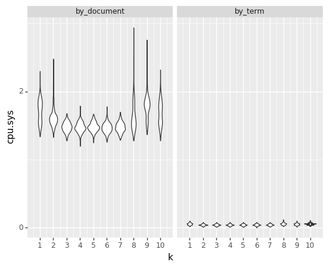

```python
(ggplot(exp_results)
 + geom_violin(aes('k', 'cpu.sys', group='k')) +
 facet_wrap('~approach') +
 scale_x_continuous(breaks = range(0,11,1)) +
 scale_y_continuous(breaks = range(0,32,2))
)
```

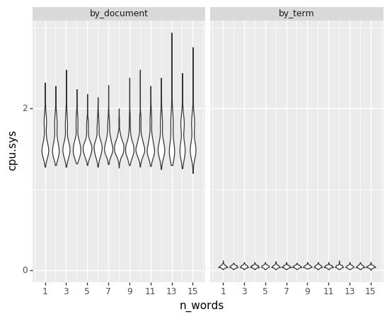

```python
(ggplot(exp_results)
 + geom_violin(aes('n_words', 'cpu.sys', group='n_words')) +
 facet_wrap('~approach') +
 scale_x_continuous(breaks = range(1,18,2)) +
 scale_y_continuous(breaks = range(0,32,2))
)
```

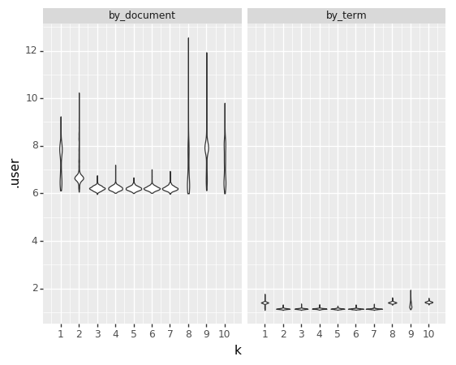

```python
(ggplot(exp_results)
 + geom_violin(aes('k', '.user', group='k')) +
 facet_wrap('~approach') +
 scale_x_continuous(breaks = range(0,11,1)) +
 scale_y_continuous(breaks = range(0,32,2))
)
```

- Throughout all values of k considered we can see quite clearly that the algorithm **by_document** seems to use at least 4 CPU-seconds more than the algorithm **by_term** whilst in **user mode**.

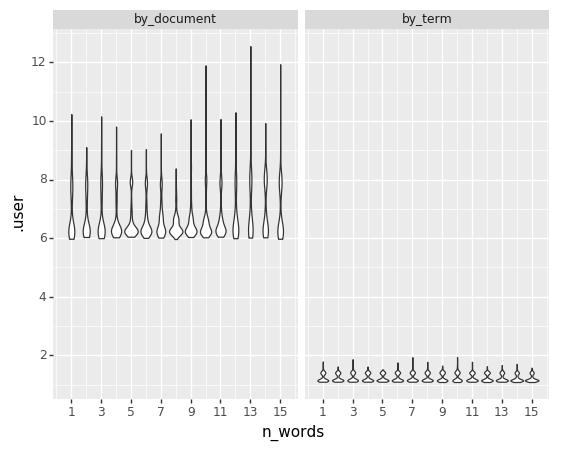

```python
(ggplot(exp_results)
 + geom_violin(aes('n_words', '.user', group='n_words')) +
 facet_wrap('~approach') +
 scale_x_continuous(breaks = range(1,18,2)) +
 scale_y_continuous(breaks = range(0,32,2))
)
```

- Throughout all values of **number of words in query** considered we can see quite clearly that the algorithm **by_document** seems to use at least 4 CPU-seconds more than the algorithm **by_term** whilst in **user mode**.

## Conjunctive Retrieval Algorithm

```python
index = index_df
query = ['juíza','Luz','Ivani']
k = 5
def conjunctive_retrieval_by_term(index, query, k):
    try:
        import Queue as Q  # ver. < 3.0
    except ImportError:
        import queue as Q

    A = {}
    result = []
    R = Q.PriorityQueue()
    q = Q.PriorityQueue()
    L = index.loc[lambda df: df.word.isin(query)]

    for idx, row in enumerate(L.itertuples()):

        if idx == 0:
            for doc_id, freq in getattr(row, "_2"):
                A[doc_id] = freq
        else:
            for doc_id, freq in getattr(row, "_2"):
                if doc_id not in A:
                    pass
                else:
                    A[doc_id] += freq

    for doc_id, score in A.items():
        q.put(((-1) * score,doc_id))

    i = 0
    while not q.empty() and i < k:
        pair = q.get()
        pair = ((-1) *pair[0],pair[1])
        result.append(pair)
        i += 1

    return result
```

## Placing some queries

```python
conj_queries = ["['nesta','55º']","['1964','ditadura']","['Humanos','Direitos']",
                "['Vladimir','Herzog']","['Vladimir','Putin']"]

conj_df = pd.DataFrame(conj_queries, columns=["query"])
conj_df["query"] = conj_df["query"].apply(lambda x: list(literal_eval(x)))
conj_df["conj_by_term"] = conj_df["query"].apply(lambda w: conjunctive_retrieval_by_term(index_df, w, k))

display(Markdown("***"))
display(Markdown("#### Result of *conjunctive retrieve by term* algorithm"))
display(HTML(conj_df.to_html(index=False)))
display(Markdown("***"))
```

Result of *conjunctive retrieve by term* algorithm

| query | conj_by_term |
| --- | --- |
| [nesta, 55º] | [(3, 0), (3, 26), (3, 85), (3, 90), (3, 111)] |
| [1964, ditadura] | [(14, 24), (11, 165), (11, 215), (10, 164), (10, 171)] |
| [Humanos, Direitos] | [(2, 0), (2, 17), (2, 100), (2, 116), (2, 152)] |
| [Vladimir, Herzog] | [(4, 0), (2, 5), (2, 237), (1, 64), (1, 85)] |
| [Vladimir, Putin] | [(3, 165), (2, 0), (2, 85), (1, 5), (1, 64)] |

## Is the implementation correct?

In order to gather some evidence regarding whether the implementation is correct let's revisit the query *juíza,Luz,Ivani*

```python
index_df.loc[index_df['word'].isin(['juíza','Luz','Ivani'])]
```

|  | word | doc_id:freq |
| --- | --- | --- |
| 0 | juíza | [(0, 2), (1, 1)] |
| 2 | Ivani | [(0, 1), (1, 1)] |
| 4 | Luz | [(0, 3), (1, 1), (124, 1)] |

As we're now using a **conjunctive** implementation only the documents that contain all the query words will be included in the result.

Consequently, the document of id=124 will be excluded as it doesn't contain neither "juíza" nor "Ivani". Finally the expected result of the *conjunctive retrieval by term* would be:

for k >= 2:

- [(6,0),(3,1)]

for k = 1:

- [(6,0)]

```python
display(Markdown("##### The actual results:"))
print("k > 2 : {}".format(conjunctive_retrieval_by_term(index_df, ['juíza','Luz','Ivani'], 10)))
print("k = 2 : {}".format(conjunctive_retrieval_by_term(index_df, ['juíza','Luz','Ivani'], 2)))
print("k = 1 : {}".format(conjunctive_retrieval_by_term(index_df, ['juíza','Luz','Ivani'], 1)))
```

The actual results:

```
k > 2 : [(6, 0), (3, 1)]
k = 2 : [(6, 0), (3, 1)]
k = 1 : [(6, 0)]
```

> The results match and thus we have some evidence that the implementation is correct.